# Course project

The goal of this project is to predict the manner in which they did the exercise to see how well they do it. The data for this project come from this source http://groupware.les.inf.puc-rio.br/har.

The training data for this project are available here https://d396qusza40orc.cloudfront.net/predmachlearn/pml-training.csv The test data are available here https://d396qusza40orc.cloudfront.net/predmachlearn/pml-testing.csv

The analysis consists of following steps:

- Data loading
- Exploratory data analysis
- Model selection
- Model evaluation
- Prediction

## Data loading

```r
training.raw <- read.csv("https://d396qusza40orc.cloudfront.net/predmachlearn/pml-training.csv")
testing.raw <- read.csv("https://d396qusza40orc.cloudfront.net/predmachlearn/pml-testing.csv")
```

## Exploratory data analysis

```r
# Review dimension of data
dim(training.raw)
```

```
## [1] 19622   160
```

```r
# following output is intentionally not shown due to excessivness information.
# check data structure
#str(training.raw)

# review summary of data; there are lots of NA.
#summary(training.raw)
# removing NA and other unused columns
```

```r
maxNA = 20
maxNACount <- nrow(training.raw) / 100 * maxNA
rmColumns <- which(colSums(is.na(training.raw) | training.raw=="") > maxNACount)
training.cleaned01 <- training.raw[,-rmColumns]
testing.cleaned01 <- testing.raw[,-rmColumns]

removeColumns <- grep("timestamp", names(training.cleaned01))
training.cleaned02 <- training.cleaned01[,-c(1, removeColumns )]
testing.cleaned02 <- testing.cleaned01[,-c(1, removeColumns )]
```

Next convert all factors to integers

```r
classLevels <- levels(training.cleaned02$classe)
training.cleaned03 <- data.frame(data.matrix(training.cleaned02))
training.cleaned03$classe <- factor(training.cleaned03$classe, labels=classLevels)
testing.cleaned03 <- data.frame(data.matrix(testing.cleaned02))
```

Next Finalize data set for analysis

```r
training.cleaned <- training.cleaned03
testing.cleaned <- testing.cleaned03
```

Next dataset is split into 70% train and 30% test.

```r
set.seed(979108)
library(caret)
classeIndex <- which(names(training.cleaned) == "classe")

partition <- createDataPartition(y=training.cleaned$classe, p=0.70, list=FALSE)
training.subSetTrain <- training.cleaned[partition, ]
training.subSetTest <- training.cleaned[-partition, ]
```

Check for fields that have high correlations with the classe

```r
correlations <- cor(training.subSetTrain[, -classeIndex], as.numeric(training.subSetTrain$classe))
bestCorrelations <- subset(as.data.frame(as.table(correlations)), abs(Freq)>0.3)
bestCorrelations
```

```
##             Var1 Var2      Freq
## 44 pitch_forearm    A 0.3428149
```

```r
library(Rmisc)
```

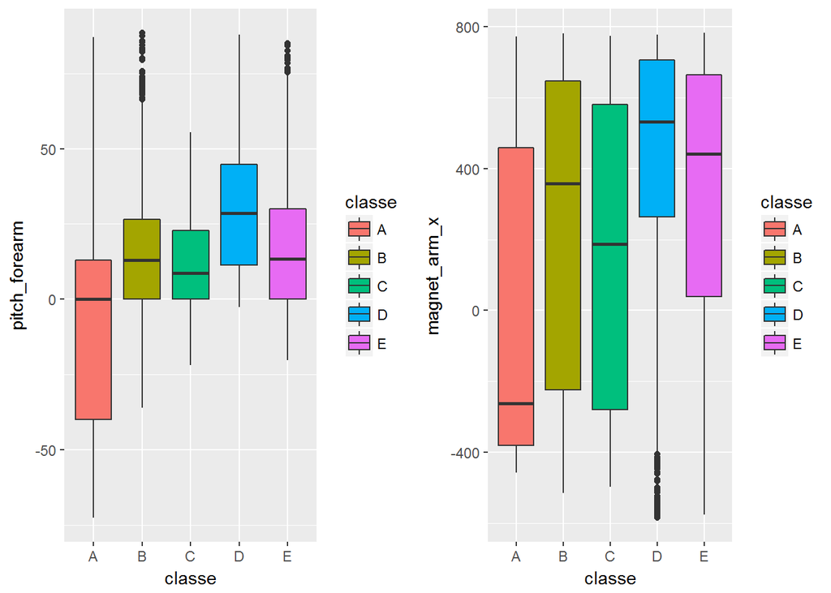

```r
library(ggplot2)

p1 <- ggplot(training.subSetTrain, aes(classe,pitch_forearm)) +
  geom_boxplot(aes(fill=classe))

p2 <- ggplot(training.subSetTrain, aes(classe, magnet_arm_x)) +
  geom_boxplot(aes(fill=classe))

multiplot(p1,p2,cols=2)
```

## Model Selection

Next, we will identify variables with high correlations amongst each other in our set so they can be excluded

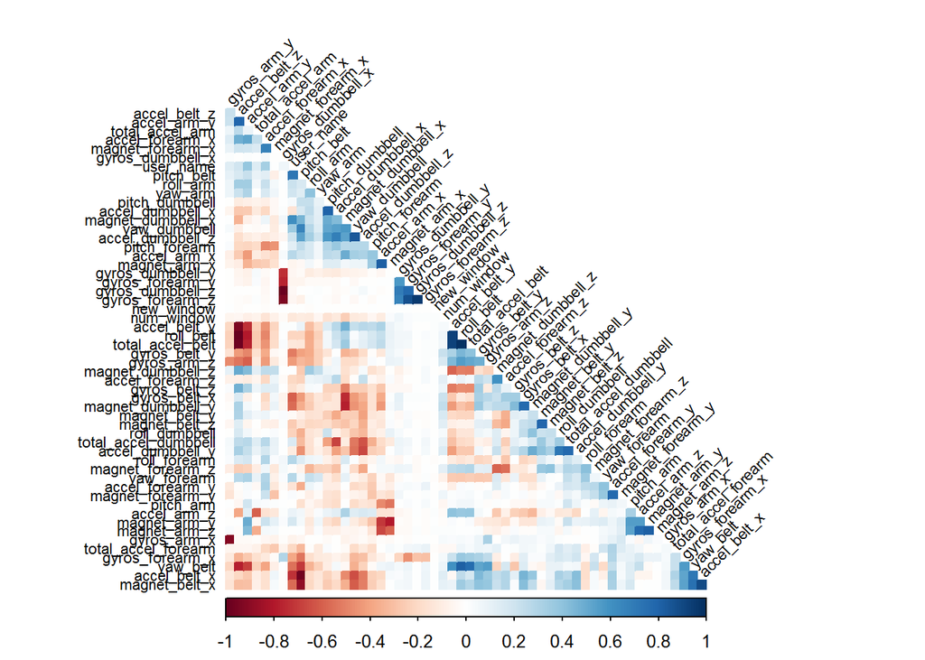

```r
library(corrplot)
correlationMatrix <- cor(training.subSetTrain[, -classeIndex])
highlyCorrelated <- findCorrelation(correlationMatrix, cutoff=0.9, exact=TRUE)
excludeColumns <- c(highlyCorrelated, classeIndex)
corrplot(correlationMatrix, method="color", type="lower", order="hclust", tl.cex=0.70, tl.col="black", tl.srt = 45, diag = FALSE)
```

According to the correlation plot, there are some features which are highly correlated. We will use PCA to reduce the dimension

```r
pcaPreProcess.all <- preProcess(training.subSetTrain[, -classeIndex], method = "pca", thresh = 0.99)
training.subSetTrain.pca.all <- predict(pcaPreProcess.all, training.subSetTrain[, -classeIndex])
training.subSetTest.pca.all <- predict(pcaPreProcess.all, training.subSetTest[, -classeIndex])
testing.pca.all <- predict(pcaPreProcess.all, testing.cleaned[, -classeIndex])


pcaPreProcess.subset <- preProcess(training.subSetTrain[, -excludeColumns], method = "pca", thresh = 0.99)
training.subSetTrain.pca.subset <- predict(pcaPreProcess.subset, training.subSetTrain[, -excludeColumns])
training.subSetTest.pca.subset <- predict(pcaPreProcess.subset, training.subSetTest[, -excludeColumns])
testing.pca.subset <- predict(pcaPreProcess.subset, testing.cleaned[, -classeIndex])
```

Let’s try random forest to train the model

```r
library(randomForest)
ntree <- 50

start <- proc.time()
rfMod.exclude <- randomForest(
  x=training.subSetTrain[, -excludeColumns],
  y=training.subSetTrain$classe,
  xtest=training.subSetTest[, -excludeColumns],
  ytest=training.subSetTest$classe,
  ntree=ntree,
  keep.forest=TRUE,
  proximity=TRUE) #do.trace=TRUE
proc.time() - start
```

```
##    user  system elapsed
##   30.20    0.61   31.26
```

```r
start <- proc.time()
rfMod.cleaned <- randomForest(
  x=training.subSetTrain[, -classeIndex],
  y=training.subSetTrain$classe,
  xtest=training.subSetTest[, -classeIndex],
  ytest=training.subSetTest$classe,
  ntree=ntree,
  keep.forest=TRUE,
  proximity=TRUE) #do.trace=TRUE
proc.time() - start
```

```
##    user  system elapsed
##   31.42    1.27   33.41
```

```r
start <- proc.time()
rfMod.pca.all <- randomForest(
  x=training.subSetTrain.pca.all,
  y=training.subSetTrain$classe,
  xtest=training.subSetTest.pca.all,
  ytest=training.subSetTest$classe,
  ntree=ntree,
  keep.forest=TRUE,
  proximity=TRUE) #do.trace=TRUE
proc.time() - start
```

```
##    user  system elapsed
##   29.05    2.72   32.24
```

## Model Evaluation

We now have 3 trained models. Let’s check for their accuracies.

```r
rfMod.cleaned
```

```
##
## Call:
##  randomForest(x = training.subSetTrain[, -classeIndex], y = training.subSetTrain$classe,      xtest = training.subSetTest[, -classeIndex], ytest = training.subSetTest$classe,      ntree = ntree, proximity = TRUE, keep.forest = TRUE)
##                Type of random forest: classification
##                      Number of trees: 50
## No. of variables tried at each split: 7
##
##         OOB estimate of  error rate: 0.53%
## Confusion matrix:
##      A    B    C    D    E  class.error
## A 3905    1    0    0    0 0.0002560164
## B    9 2642    6    0    1 0.0060195636
## C    0   15 2374    6    1 0.0091819699
## D    1    0   21 2229    1 0.0102131439
## E    0    1    0   10 2514 0.0043564356
##                 Test set error rate: 0.24%
## Confusion matrix:
##      A    B    C   D    E class.error
## A 1674    0    0   0    0 0.000000000
## B    0 1137    2   0    0 0.001755926
## C    0    0 1026   0    0 0.000000000
## D    0    0    7 957    0 0.007261411
## E    0    0    0   5 1077 0.004621072
```

```r
rfMod.cleaned.training.acc <- round(1-sum(rfMod.cleaned$confusion[, 'class.error']),3)
paste0("Accuracy on training: ",rfMod.cleaned.training.acc)
```

```
## [1] "Accuracy on training: 0.97"
```

```r
rfMod.cleaned.testing.acc <- round(1-sum(rfMod.cleaned$test$confusion[, 'class.error']),3)
paste0("Accuracy on testing: ",rfMod.cleaned.testing.acc)
```

```
## [1] "Accuracy on testing: 0.986"
```

```r
rfMod.exclude
```

```
##
## Call:
##  randomForest(x = training.subSetTrain[, -excludeColumns], y = training.subSetTrain$classe,      xtest = training.subSetTest[, -excludeColumns], ytest = training.subSetTest$classe,      ntree = ntree, proximity = TRUE, keep.forest = TRUE)
##                Type of random forest: classification
##                      Number of trees: 50
## No. of variables tried at each split: 6
##
##         OOB estimate of  error rate: 0.5%
## Confusion matrix:
##      A    B    C    D    E  class.error
## A 3903    2    0    1    0 0.0007680492
## B   11 2639    8    0    0 0.0071482318
## C    0   19 2375    2    0 0.0087646077
## D    1    0   15 2234    2 0.0079928952
## E    0    1    0    7 2517 0.0031683168
##                 Test set error rate: 0.24%
## Confusion matrix:
##      A    B    C   D    E  class.error
## A 1674    0    0   0    0 0.0000000000
## B    0 1138    1   0    0 0.0008779631
## C    0    3 1023   0    0 0.0029239766
## D    0    0    4 960    0 0.0041493776
## E    0    0    0   6 1076 0.0055452865
```

```r
rfMod.exclude.training.acc <- round(1-sum(rfMod.exclude$confusion[, 'class.error']),3)
paste0("Accuracy on training: ",rfMod.exclude.training.acc)
```

```
## [1] "Accuracy on training: 0.972"
```

```r
rfMod.exclude.testing.acc <- round(1-sum(rfMod.exclude$test$confusion[, 'class.error']),3)
paste0("Accuracy on testing: ",rfMod.exclude.testing.acc)
```

```
## [1] "Accuracy on testing: 0.987"
```

```r
rfMod.pca.all
```

```
##
## Call:
##  randomForest(x = training.subSetTrain.pca.all, y = training.subSetTrain$classe,      xtest = training.subSetTest.pca.all, ytest = training.subSetTest$classe,      ntree = ntree, proximity = TRUE, keep.forest = TRUE)
##                Type of random forest: classification
##                      Number of trees: 50
## No. of variables tried at each split: 6
##
##         OOB estimate of  error rate: 3.3%
## Confusion matrix:
##      A    B    C    D    E class.error
## A 3863   21    7    8    7  0.01100870
## B   73 2543   29    3   10  0.04326561
## C   10   42 2309   30    5  0.03631052
## D    7    3  106 2119   17  0.05905861
## E    7   19   23   26 2450  0.02970297
##                 Test set error rate: 2.18%
## Confusion matrix:
##      A    B   C   D    E class.error
## A 1666    2   3   2    1 0.004778973
## B   15 1106  12   5    1 0.028972783
## C    4   15 996  11    0 0.029239766
## D    1    0  37 925    1 0.040456432
## E    3    3   7   5 1064 0.016635860
```

```r
rfMod.pca.all.training.acc <- round(1-sum(rfMod.pca.all$confusion[, 'class.error']),3)
paste0("Accuracy on training: ",rfMod.pca.all.training.acc)
```

```
## [1] "Accuracy on training: 0.821"
```

```r
rfMod.pca.all.testing.acc <- round(1-sum(rfMod.pca.all$test$confusion[, 'class.error']),3)
paste0("Accuracy on testing: ",rfMod.pca.all.testing.acc)
```

```
## [1] "Accuracy on testing: 0.88"
```

As shown, rfMod.exclude model performs better among other 3 models.

## Prediction

Now let’s prediction using the best models compared to other less performed models

```r
predictions <- t(cbind(
    exclude=as.data.frame(predict(rfMod.exclude, testing.cleaned[, -excludeColumns]), optional=TRUE),
    cleaned=as.data.frame(predict(rfMod.cleaned, testing.cleaned), optional=TRUE),
    pcaAll=as.data.frame(predict(rfMod.pca.all, testing.pca.all), optional=TRUE)
))
predictions
```

```
##         1   2   3   4   5   6   7   8   9   10  11  12  13  14  15  16
## exclude "B" "A" "B" "A" "A" "E" "D" "B" "A" "A" "B" "C" "B" "A" "E" "E"
## cleaned "B" "A" "B" "A" "A" "E" "D" "B" "A" "A" "B" "C" "B" "A" "E" "E"
## pcaAll  "B" "A" "B" "A" "A" "E" "D" "B" "A" "A" "B" "C" "B" "A" "E" "E"
##         17  18  19  20
## exclude "A" "B" "B" "B"
## cleaned "A" "B" "B" "B"
## pcaAll  "A" "B" "B" "B"
```

As shown, the best model does not really outperform others very much in terms of prediction. However, since it gave better accuary, we will still choose it over others.